# R Notebook

Introduction

Today we will be analyzing the titanic dataset. We will use various ML models, different cross validation(CV) tools, and feature selection to see which models gives us the best prediction. This is a kaggle competition.

| PassengerId | Survived | Pclass | Name | Sex | Age | SibSp | Parch | Ticket | Fare | Cabin | Embarked | Type.of.data |
| --- | --- | --- | --- | --- | --- | --- | --- | --- | --- | --- | --- | --- |
| 1 | 0 | 3 | Braund, Mr. Owen Harris | male | 22 | 1 | 0 | A/5 21171 | 7.2500 | NA | S | Train.data |
| 2 | 1 | 1 | Cumings, Mrs. John Bradley (Florence Briggs Thayer) | female | 38 | 1 | 0 | PC 17599 | 71.2833 | C85 | C | Train.data |
| 3 | 1 | 3 | Heikkinen, Miss. Laina | female | 26 | 0 | 0 | STON/O2. 3101282 | 7.9250 | NA | S | Train.data |
| 4 | 1 | 1 | Futrelle, Mrs. Jacques Heath (Lily May Peel) | female | 35 | 1 | 0 | 113803 | 53.1000 | C123 | S | Train.data |
| 5 | 0 | 3 | Allen, Mr. William Henry | male | 35 | 0 | 0 | 373450 | 8.0500 | NA | S | Train.data |
| 6 | 0 | 3 | Moran, Mr. James | male | NA | 0 | 0 | 330877 | 8.4583 | NA | Q | Train.data |

Data preprocessing

Our first step is to modify the varibales to their repsective categories: numeric, categorical, and then we will assess the missing values

Now we will assess missing values in our dataset

```
             [,1]
PassengerId     0
Survived      418
Pclass          0
Name            0
Sex             0
Age           263
SibSp           0
Parch           0
Ticket          0
Fare            1
Cabin        1014
Embarked        2
Type.of.data    0
```

These are the missing values we are able to find. *Age and Cabin* has the most missing values and *Fare and Embarked* has the least missing values

We will try to perform *EDA* and see if we can get any insights on how to impute these missing values

EDA

EDA Analysis 1: Age

*Histogram of age*

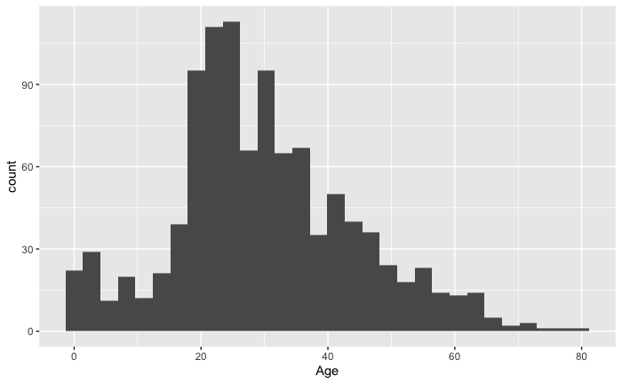

We see that age is rouhgly normally distributed

We will now see how *Age* correlates with the categogical varibales

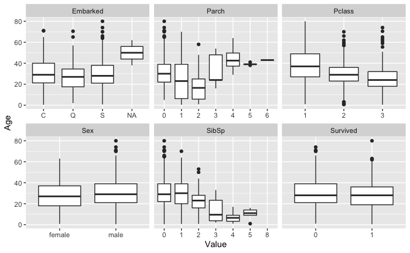

From the looks of this, there seem to be some pattern with Age and Pclass, so we will take a further analysis into this. We are not dealing with *Parch and SibSp* just yet since they both seem to be correlated with each other

We will explore more with *Age and Pclass*

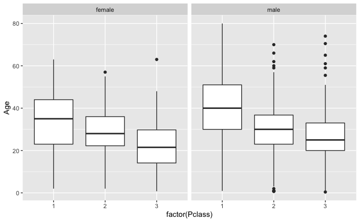

From the looks of this, we can impute *Medain* values for the age based on Sex and Pclass

*Updated histogram for Age*

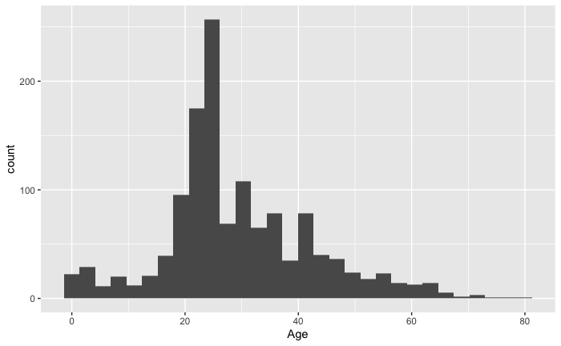

```
Null deviance: 1186.7  on 890  degrees of freedom
```

Residual deviance: 390.6 on 887 degrees of freedom AIC: 398.6

Number of Fisher Scoring iterations: 15

[output not shown]

```
[1] 0.9416386
```

```r
mean(ifelse(predict(logit.stacking.train, newdata = stacking.test , type = "response")>0.5,1,0)==real.values)
```

```
[1] 0.7942584
```

```r
final.pred<-rep(0, nrow(test.data))
final.pred[which(predict(logit.stacking.train, newdata = stacking.test , type = "response")>0.5)]<-1
dput(final.pred)
```

[output not shown]